# NKE Financial Report

Financial Overview

2025-11-02

## Report on the Overall Status of NKE

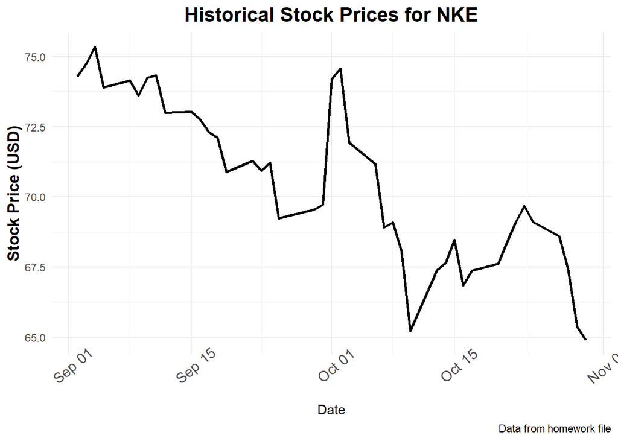

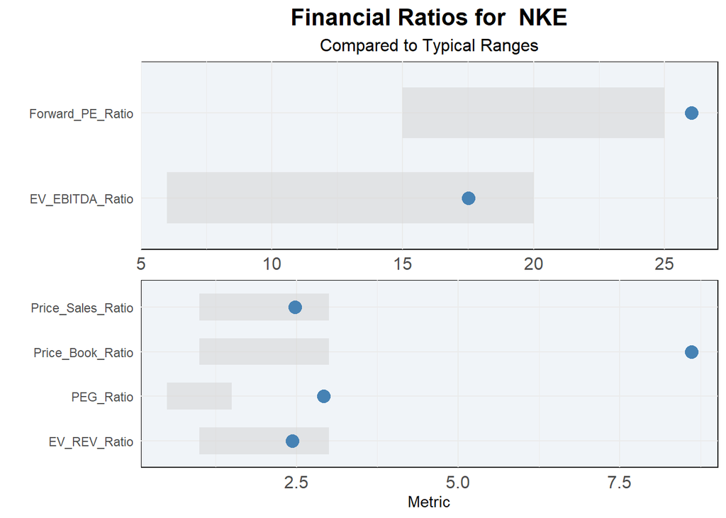

## Data Interpretation

### P/E Forward

**Definition**: The P/E Forward ratio compares a company’s current share price to its expected earnings per share over the next 12 months. It helps investors assess valuation based on future profitability.

**Typical Range**:  
- < 15: Undervalued or mature  
- 15–25: Fairly valued  
- > 25: High growth expectations

### PEG Ratio

**Definition**: The PEG ratio adjusts the P/E ratio by factoring in expected earnings growth, offering a more nuanced valuation. **Typical Range**:  
- < 1: Undervalued  
- ≈ 1: Fairly valued  
- > 1: Overvalued

### Price/Sales

**Definition**: This ratio compares a company’s market capitalization to its total revenue. It’s useful for evaluating companies with little or no earnings.  
**Typical Range**:  
- < 1: Undervalued  
- 1–3: Reasonable  
- > 3: High expectations

### Price/Book

**Definition**: The P/B ratio compares market value to book value, indicating how much investors are willing to pay for net assets.

**Typical Range**:  
- < 1: Possibly undervalued  
- 1–3: Normal  
- > 3: Premium valuation

### EV/Revenue

**Definition**: This ratio compares a company’s total value (including debt) to its revenue. It’s useful for comparing companies with different capital structures.

**Typical Range**:  
- < 1: Undervalued  
- 1–3: Reasonable  
- > 3: High growth expectations

### EV/EBITDA

**Definition**: EV/EBITDA measures a company’s total value relative to its earnings before interest, taxes, depreciation, and amortization. It’s widely used for valuation across industries.